# Quiz 4

Amy Su Jiang

### Question 1

Load the vowel.train and vowel.test data sets:

library(ElemStatLearn) data(vowel.train) data(vowel.test)

Set the variable y to be a factor variable in both the training and test set. Then set the seed to 33833. Fit (1) a random forest predictor relating the factor variable y to the remaining variables and (2) a boosted predictor using the “gbm” method. Fit these both with the train() command in the caret package.

What are the accuracies for the two approaches on the test data set? What is the accuracy among the test set samples where the two methods agree?

```
RF Accuracy = 0.3233
GBM Accuracy = 0.8371
Agreement Accuracy = 0.9983
RF Accuracy = 0.9881
GBM Accuracy = 0.5325
Agreement Accuracy = 0.9973
RF Accuracy = 0.9881
GBM Accuracy = 0.8371
Agreement Accuracy = 0.9983
RF Accuracy = 0.6061
GBM Accuracy = 0.5325
Agreement Accuracy = 0.6518
```

```r
library(caret)
library(ElemStatLearn)
library(gbm)
data(vowel.train)
data(vowel.test)

vowel.train$y <- as.factor(vowel.train$y)
vowel.test$y <- as.factor(vowel.test$y)

set.seed(33833)
model1 <- train(y~., method="rf", data = vowel.train)
model2 <- train(y~., method="gbm", data = vowel.train)

model1.predict <- predict(model1, newdata = vowel.test)
model2.predict <- predict(model2, newdata = vowel.test)

hat <- data.frame(model1.predict,
model2.predict,
y = vowel.test$y,
agree = model1.predict == model2.predict)

sum(model1.predict[hat$agree] == hat$y[hat$agree]) / sum(hat$agree)

data.combined <- data.frame(model1.predict, model2.predict, y = vowel.test$y)
model.combined <- train(y ~ ., data = data.combined, method = "rf")
predict.combined <- predict(model.combined, newdata = vowel.test)
```

[output not shown]

```r
confusionMatrix(model1.predict, vowel.test$y)$overall
```

```
##       Accuracy          Kappa  AccuracyLower  AccuracyUpper   AccuracyNull
##   6.060606e-01   5.666667e-01   5.598599e-01   6.508944e-01   9.090909e-02
## AccuracyPValue  McnemarPValue
##  1.028868e-166            NaN
```

```r
confusionMatrix(model2.predict, vowel.test$y)$overall
```

```
##       Accuracy          Kappa  AccuracyLower  AccuracyUpper   AccuracyNull
##   5.303030e-01   4.833333e-01   4.836421e-01   5.765737e-01   9.090909e-02
## AccuracyPValue  McnemarPValue
##  1.563047e-127            NaN
```

```r
confusionMatrix(predict.combined, vowel.test$y)$overall
```

```
##       Accuracy          Kappa  AccuracyLower  AccuracyUpper   AccuracyNull
##   6.969697e-01   6.666667e-01   6.528153e-01   7.385808e-01   9.090909e-02
## AccuracyPValue  McnemarPValue
##  3.791735e-220            NaN
```

### Question 2

Load the Alzheimer’s data using the following commands

```
library(caret)
library(gbm)
set.seed(3433)
library(AppliedPredictiveModeling)
data(AlzheimerDisease)
adData = data.frame(diagnosis,predictors)
inTrain = createDataPartition(adData$diagnosis, p = 3/4)[[1]]
training = adData[ inTrain,]
testing = adData[-inTrain,]
```

Set the seed to 62433 and predict diagnosis with all the other variables using a random forest (“rf”), boosted trees (“gbm”) and linear discriminant analysis (“lda”) model. Stack the predictions together using random forests (“rf”). What is the resulting accuracy on the test set? Is it better or worse than each of the individual predictions?

```
Stacked Accuracy: 0.79 is better than random forests and lda and the same as boosting.
Stacked Accuracy: 0.79 is better than all three other methods
Stacked Accuracy: 0.76 is better than random forests and boosting, but not lda.
Stacked Accuracy: 0.69 is better than all three other methods
```

```r
library(caret)
library(gbm)
set.seed(3433)
library(AppliedPredictiveModeling)
data(AlzheimerDisease)
adData = data.frame(diagnosis,predictors)
inTrain = createDataPartition(adData$diagnosis, p = 3/4)[[1]]
training = adData[ inTrain,]
testing = adData[-inTrain,]

set.seed(62433)
model1 <- train(diagnosis ~ ., data=training, method="rf")
model2 <- train(diagnosis ~ ., data=training, method="gbm")
model3 <- train(diagnosis ~ ., data=training, method="lda")
model1.predict <- predict(model1, testing)
model2.predict <- predict(model2, testing)
model3.predict <- predict(model3, testing)
data.combined <- data.frame(model1.predict, model2.predict, model3.predict, diagnosis=testing$diagnosis)
model.combined <- train(diagnosis ~ ., data=data.combined, method="rf")
predict.combined <- predict(model.combined, testing)
```

```r
confusionMatrix(model1.predict, testing$diagnosis)$overall
```

```
##       Accuracy          Kappa  AccuracyLower  AccuracyUpper   AccuracyNull
##      0.7682927      0.3832146      0.6620479      0.8543612      0.7317073
## AccuracyPValue  McnemarPValue
##      0.2706781      0.6463552
```

```r
confusionMatrix(model2.predict, testing$diagnosis)$overall
```

```
##       Accuracy          Kappa  AccuracyLower  AccuracyUpper   AccuracyNull
##      0.7926829      0.4794623      0.6889483      0.8743420      0.7317073
## AccuracyPValue  McnemarPValue
##      0.1297117      1.0000000
```

```r
confusionMatrix(model3.predict, testing$diagnosis)$overall
```

```
##       Accuracy          Kappa  AccuracyLower  AccuracyUpper   AccuracyNull
##      0.7682927      0.4638679      0.6620479      0.8543612      0.7317073
## AccuracyPValue  McnemarPValue
##      0.2706781      0.1686686
```

```r
confusionMatrix(predict.combined, testing$diagnosis)$overall
```

```
##       Accuracy          Kappa  AccuracyLower  AccuracyUpper   AccuracyNull
##     0.80487805     0.45605307     0.70256400     0.88415731     0.73170732
## AccuracyPValue  McnemarPValue
##     0.08207861     0.21129955
```

### Question 3

Load the concrete data with the commands:

```
set.seed(3523)
library(AppliedPredictiveModeling)
data(concrete)
inTrain = createDataPartition(concrete$CompressiveStrength, p = 3/4)[[1]]
training = concrete[ inTrain,]
testing = concrete[-inTrain,]
```

Set the seed to 233 and fit a lasso model to predict Compressive Strength. Which variable is the last coefficient to be set to zero as the penalty increases? (Hint: it may be useful to look up ?plot.enet).

```
Cement
FineAggregate
CoarseAggregate
Age
```

```r
set.seed(3523)
library(AppliedPredictiveModeling)
data(concrete)
inTrain = createDataPartition(concrete$CompressiveStrength, p = 3/4)[[1]]
training = concrete[ inTrain,]
testing = concrete[-inTrain,]

set.seed = 233
model1  <- train(CompressiveStrength~., method = "lasso", training)
```

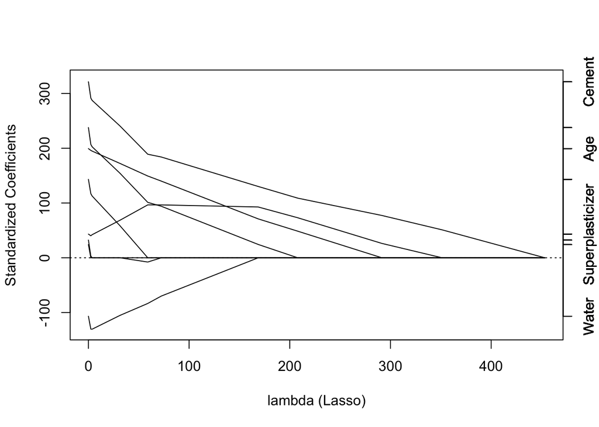

```r
plot.enet(model1$finalModel, xvar="penalty")
```

### Question 4

Load the data on the number of visitors to the instructors blog from here: https://d396qusza40orc.cloudfront.net/predmachlearn/gaData.csv

Using the commands:

```
library(lubridate)  # For year() function below
dat = read.csv("~/Desktop/gaData.csv")
training = dat[year(dat$date) < 2012,]
testing = dat[(year(dat$date)) > 2011,]
tstrain = ts(training$visitsTumblr)
```

Fit a model using the bats() function in the forecast package to the training time series. Then forecast this model for the remaining time points. For how many of the testing points is the true value within the 95% prediction interval bounds?

```
96%
95%
92%
94%
```

```r
library(lubridate)
library(forecast)
```

```r
if(!"goData.csv" %in% dir("./")) {
    download.file(url = "http://d396qusza40orc.cloudfront.net/predmachlearn/gaData.csv", destfile = "goData.csv")
}
data <- read.csv("goData.csv", header = TRUE)
training = data[year(data$date) < 2012,]
testing = data[(year(data$date)) > 2011,]
training.ts = ts(training$visitsTumblr)

model1 <- bats(training.ts)
nrow(testing)
```

```
## [1] 235
```

```r
model1.forecast <- forecast(model1, level = 95, h=235)

accuracy(model1.forecast, testing$visitsTumblr)
```

```
##                     ME     RMSE       MAE      MPE     MAPE      MASE
## Training set  10.39787 258.7813  40.22707     -Inf      Inf 0.8437138
## Test set     185.20149 301.2620 205.87807 26.06409 40.76475 4.3180420
##                  ACF1
## Training set 0.012104
## Test set           NA
```

```r
result <- c()
l <- length(model1.forecast$lower)
for (i in 1:l){
x <- testing$visitsTumblr[i]
a <- model1.forecast$lower[i] < x & x < model1.forecast$upper[i]
result <- c(result, a)
}
sum(result)/l * 100
```

```
## [1] 96.17021
```

### Question 5

Load the concrete data with the commands:

```
set.seed(3523)
library(AppliedPredictiveModeling)
data(concrete)
inTrain = createDataPartition(concrete$CompressiveStrength, p = 3/4)[[1]]
training = concrete[ inTrain,]
testing = concrete[-inTrain,]
```

Set the seed to 325 and fit a support vector machine using the e1071 package to predict Compressive Strength using the default settings. Predict on the testing set. What is the RMSE?

```
45.09
6.93
35.59
6.72
```

```r
set.seed(3523)
library(AppliedPredictiveModeling)
data(concrete)
inTrain = createDataPartition(concrete$CompressiveStrength, p = 3/4)[[1]]
training = concrete[ inTrain,]
testing = concrete[-inTrain,]

set.seed = 325
library(e1071)
library(caret)
model1 <- svm(CompressiveStrength~., training)
model1.predict  <- predict(model1, testing)
accuracy(model1.predict, testing$CompressiveStrength)
```

```
##                 ME     RMSE      MAE       MPE     MAPE
## Test set 0.1682863 6.715009 5.120835 -7.102348 19.27739
```